# Task 3: 基于RFM的客户价值分层分析

CAIWEI ZHANG

在建立营销模型之前，需要对客户有初步的了解，RFM的分层方法是比较常用的方法。RFM的含义：

**R（Recency）最近一次消费时间**：表示用户最近一次消费距离现在的时间。消费时间越近的客户价值越大。1年前消费过的用户肯定没有1周前消费过的用户价值大。

**F（Frequency）消费频率**：消费频率是指用户在统计周期内购买商品的次数，经常购买的用户也就是熟客，价值肯定比偶尔来一次的客户价值大。

**M（Monetary）消费金额**：消费金额是指用户在统计周期内消费的总金额，体现了消费者为企业创利的多少，自然是消费越多的用户价值越大。

通过三个维度可以把客户分为8组：

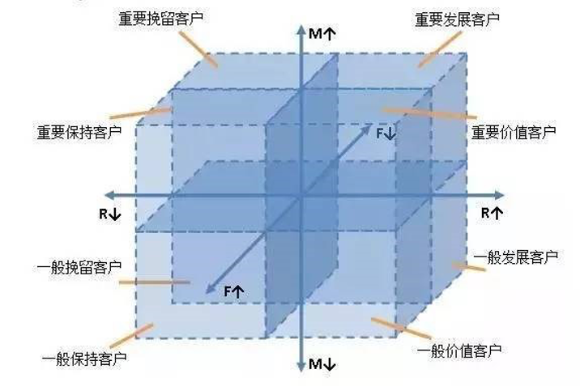

## 任务

根据Task 2，在进行模型建立前我们首先删除非正常交易的449个样本(只在交易表中出现而没有在客户表中出现)， 并在交易表(trans)中将观察窗口(1998-1-1至1998-6-30)中的交易记录提取出来：

```r
trans_obj <- trans[!trans$account_id %in% trans_no_app, ] %>%
  filter(date > as.Date("1998-01-01") & date < as.Date("1998-06-30"))

# 查看一共有多少账户在统计周期内进行了多少次交易
sprintf("一共有 %d 账户在统计周期内进行了 %d 交易",
        length(unique(trans_obj$account_id)), nrow(trans_obj))
```

```
## [1] "一共有 4033 账户在统计周期内进行了 144679 交易"
```

### Q1. 每一个客户的某种交易的R，F，M指标

分别提取不同交易类型的数据，

```r
trans_rfm <- trans_obj %>% group_by(account_id, operation) %>%
               mutate(recency = max(date)) %>% mutate(frequency = n()) %>%
               mutate(monetary = sum(amount_num)) %>%
               select(account_id, operation, recency, frequency, monetary)
trans_rfm <- trans_rfm[!duplicated(trans_rfm), ]

rTime <- trans_obj %>% group_by(operation) %>% mutate(refertime = max(date)) %>%
  select(operation, refertime)
rTime <- rTime[!duplicated(rTime), ]

trans_rfm <- inner_join(trans_rfm, rTime, by = "operation")
trans_rfm$rInternal <- as.integer(as.Date(trans_rfm$recency) - as.Date(trans_rfm$refertime))
trans_rfm <- select(trans_rfm, -c(refertime))

operation <- unique(trans_obj$operation)
for (op in operation) {
  assign(paste0("trans_", op), trans_rfm[trans_rfm$operation == op, ])
}
```

对于6类交易类型，我们分别计算了相应的R，F，M指标，并保存在相应文件中。

分析loan交易对应的R，F，M指标的分布，

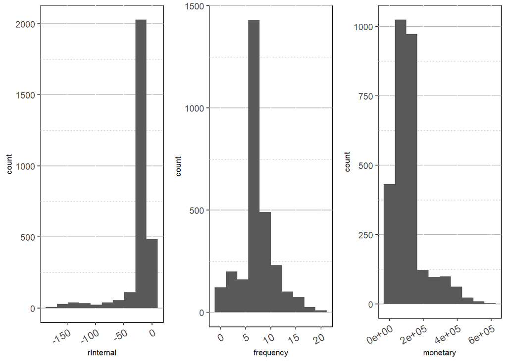

```r
## 绘制recency, frequency, monetary的直方图，观察其分布
r <- ggplot(trans_loan, aes(rInternal)) +
      geom_histogram(bins = 10) + mytheme
f <- ggplot(trans_loan, aes(frequency)) +
  geom_histogram(bins = 10) + mytheme
m <- ggplot(trans_loan, aes(monetary)) +
  geom_histogram(bins = 10) + mytheme
gridExtra::grid.arrange(r, f, m, ncol = 3)
```

通过上图可以看出，最近一次交易时间大多数发生在观察窗口结束时间的前一个月之内；交易频次大多是在5-10次之间，低频次交易的人数比高频词交易的人数多；交易总额集中在15万以内。

### Q2. 对三个维度，分别划分等级，列明等级划分标准，说明等级划分的理由。

**划分等级标准1**：对于原始R,F,M的取值，大于平均数认为“高等级”，小于平均数认为“低等级”。

我们以交易类型“loan”为例，按照平均值划分标准来划分客户等级。

```r
trans_loan$rankR <- ifelse(trans_loan$rInternal > mean(trans_loan$rInternal), "高", "低")
trans_loan$rankF <- ifelse(trans_loan$frequency > mean(trans_loan$frequency), "高", "低")
trans_loan$rankM <- ifelse(trans_loan$monetary > mean(trans_loan$monetary), "高", "低")

label <- vector("character", nrow(trans_loan))
trans_loan_lab <- within(trans_loan, {

  label[rankR == "高" & rankF == "高" & rankM == "高"] = "重要价值客户"
  label[rankR == "高" & rankF == "低" & rankM == "高"] = "重要发展客户"
  label[rankR == "低" & rankF == "高" & rankM == "高"] = "重要保持客户"
  label[rankR == "低" & rankF == "低" & rankM == "高"] = "重要挽留客户"

  label[rankR == "高" & rankF == "高" & rankM == "低"] = "一般价值客户"
  label[rankR == "高" & rankF == "低" & rankM == "低"] = "一般发展客户"
  label[rankR == "低" & rankF == "高" & rankM == "低"] = "一般保持客户"
  label[rankR == "低" & rankF == "低" & rankM == "低"] = "一般挽留客户"

})

trans_loan_lab %>% group_by(label) %>%
  summarize(rmean = mean(rInternal), rmedian = median(rInternal), rsd = sd(rInternal),
            fmean = mean(frequency), fmedian = median(frequency), fsd = sd(frequency),
            mmean = mean(monetary),  mmedian = median(monetary),  msd = sd(monetary),
            .groups = "drop")
```

```
## # A tibble: 8 x 10
##   label         rmean rmedian   rsd fmean fmedian    fsd   mmean mmedian     msd
##   <chr>         <dbl>   <dbl> <dbl> <dbl>   <dbl>  <dbl>   <dbl>   <dbl>   <dbl>
## 1 一般保持客户 -26      -26   NA     9          9 NA     102599  102599      NA
## 2 一般发展客户 -16.9    -18    6.18  5.78       6  1.33   67715.  73800   32636.
## 3 一般价值客户 -15.0    -16    6.68 10.1        9  2.25   64330.  62189   23062.
## 4 一般挽留客户 -85.4    -79.5 46.6   2.48       2  1.54   22326.   8400   28686.
## 5 重要保持客户 -36.8    -34   10.3  10.7       10  2.48  267037. 252152.  90491.
## 6 重要发展客户 -18.0    -19    5.33  6.12       6  0.441 139477. 137180.  18010.
## 7 重要价值客户  -9.96    -8    7.35 11.8       11  2.82  282704. 282949  105801.
## 8 重要挽留客户 -44.4    -42   16.9   5.90       6  0.889 166351. 159798   34315.
```

将8个客户组的recency，frequency，monetary的均值、中位数和方差，汇总如下：

loan交易中客户R，F，M指标的统计量汇总

| 客户类型 | R均值 | R中位数 | R标准差 | F均值 | F中位数 | F标准差 | M均值 | M中位数 | M标准差 |
| --- | --- | --- | --- | --- | --- | --- | --- | --- | --- |
| 重要价值客户 | -9.96 | -8 | 7.35 | 11.8 | 11 | 2.82 | 2.83e5 | 282949 | 105801 |
| 重要发展客户 | -18.0 | -19 | 5.33 | 6.12 | 6 | 0.441 | 1.39e5 | 137180 | 18010 |
| 重要保持客户 | -36.8 | -34 | 10.3 | 10.7 | 10 | 2.48 | 2.67e5 | 252152 | 90491 |
| 重要挽留客户 | -44.4 | -42 | 16.9 | 5.90 | 6 | 0.889 | 1.66e5 | 159798 | 34315 |
| 一般价值客户 | -15.0 | -16 | 6.68 | 10.1 | 9 | 2.25 | 6.43e4 | 62189 | 23062 |
| 一般发展客户 | -16.9 | -18 | 6.18 | 5.78 | 6 | 1.33 | 6.77e4 | 73800 | 32636 |
| 一般保持客户 | -26 | -26 | 0 | 9 | 9 | 0 | 1.03e5 | 102599 | 0 |
| 一般挽留客户 | -85.4 | -79.5 | 46.6 | 2.48 | 2 | 1.54 | 2.23e4 | 8400 | 28686 |

### Q3. 计算每个单元用户数和占比情况：

计算loan交易对应的客户分层情况，

将分层情况汇总如下表：

loan交易客户分层情况统计表

| 客户类型 | 计数 | 占比 | 成交客户等级 |
| --- | --- | --- | --- |
| 重要价值客户 | 395 | 0.1387 | A级 |
| 重要发展客户 | 664 | 0.2331 | A级 |
| 重要保持客户 | 50 | 0.0176 | B级 |
| 重要挽留客户 | 41 | 0.0144 | B级 |
| 一般价值客户 | 488 | 0.1713 | B级 |
| 一般发展客户 | 901 | 0.3164 | B级 |
| 一般保持客户 | 1 | 0.0004 | C级 |
| 一般挽留客户 | 308 | 0.1081 | C级 |

绘制loan交易对应的客户分层条形图如下：

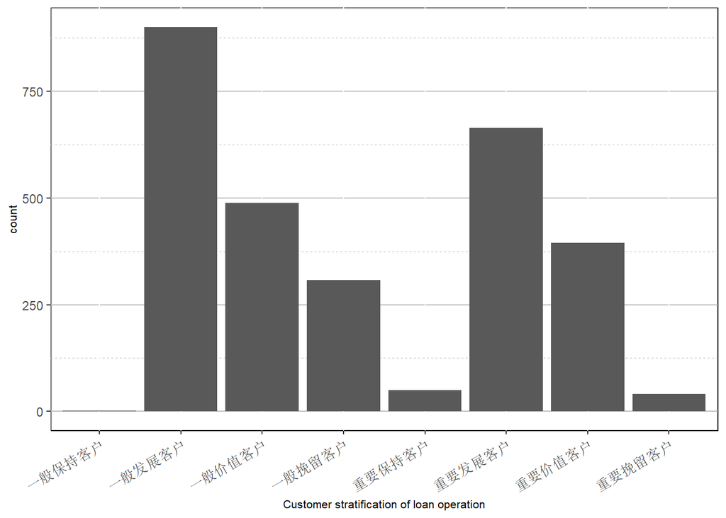

```r
# 绘制客户类型分布的条形图
ggplot(data = trans_loan_lab) + geom_bar(mapping = aes(x = label)) +
  xlab("Customer stratification of loan operation") + mytheme
```

根据上图和表1可以看出,“一般保持客户”，“重要保持客户”和“重要挽留客户”非常少，说明两点问题： (1) “一般保持客户”极少，“重要保持客户”非常少，说明很少出现最近一次交易距离远但交易频次高的情况。 (2) “重要挽留客户”非常少，说明很少出现最近一次交易距离远，交易频次低但是交易金额大的，对照“一般挽留客户”的人数，可以发现最近一次交易距离远，交易频次低的客户，通常交易金额也低，很少会单次进行大额交易。

另外，A及客户（“重要价值客户”和“重要发展客户”）数量可观，可以针对这些客户提供针对性的服务。“一般发展客户”最多，这类客户的交易金额和频次都低，可能是在临近观察期结束的时间内进行了少数交易。尽管这类客户价值有限，但是数量最大，也可以针对这类客户做营销。

下面按照类似的操作，将其余5种交易类型的客户分层情况分别汇总至表 3-7：

cash交易客户分层情况统计表

| 客户类型 | 计数 | 占比 | 成交客户等级 |
| --- | --- | --- | --- |
| 重要价值客户 | 740 | 0.1837 | A级 |
| 重要发展客户 | 229 | 0.0568 | A级 |
| 重要保持客户 | 317 | 0.0787 | B级 |
| 重要挽留客户 | 167 | 0.0414 | B级 |
| 一般价值客户 | 567 | 0.1407 | B级 |
| 一般发展客户 | 685 | 0.1700 | B级 |
| 一般保持客户 | 347 | 0.0861 | C级 |
| 一般挽留客户 | 977 | 0.2425 | C级 |

remit交易客户分层情况统计表

| 客户类型 | 计数 | 占比 | 成交客户等级 |
| --- | --- | --- | --- |
| 重要价值客户 | 550 | 0.1740 | A级 |
| 重要发展客户 | 276 | 0.0873 | A级 |
| 重要保持客户 | 136 | 0.0430 | B级 |
| 重要挽留客户 | 315 | 0.0997 | B级 |
| 一般价值客户 | 391 | 0.1237 | B级 |
| 一般发展客户 | 588 | 0.1860 | B级 |
| 一般保持客户 | 172 | 0.0544 | C级 |
| 一般挽留客户 | 733 | 0.2319 | C级 |

collection交易客户分层情况统计表

| 客户类型 | 计数 | 占比 | 成交客户等级 |
| --- | --- | --- | --- |
| 重要发展客户 | 158 | 0.1084 | A级 |
| 重要挽留客户 | 215 | 0.1476 | B级 |
| 一般发展客户 | 564 | 0.3871 | B级 |
| 一般挽留客户 | 520 | 0.3569 | C级 |

debit交易客户分层情况统计表

| 客户类型 | 计数 | 占比 | 成交客户等级 |
| --- | --- | --- | --- |
| 重要价值客户 | 128 | 0.2759 | A级 |
| 重要发展客户 | 11 | 0.0237 | A级 |
| 重要保持客户 | 57 | 0.1228 | B级 |
| 重要挽留客户 | 6 | 0.0129 | B级 |
| 一般价值客户 | 9 | 0.0194 | B级 |
| 一般发展客户 | 118 | 0.2543 | B级 |
| 一般保持客户 | 11 | 0.0237 | C级 |
| 一般挽留客户 | 124 | 0.2672 | C级 |

unknown交易客户分层情况统计表

| 客户类型 | 计数 | 占比 | 成交客户等级 |
| --- | --- | --- | --- |
| 重要价值客户 | 101 | 0.0253 | A级 |
| 重要发展客户 | 1604 | 0.4013 | A级 |
| 重要挽留客户 | 1 | 0.0003 | B级 |
| 一般价值客户 | 36 | 0.0090 | B级 |
| 一般发展客户 | 2224 | 0.5564 | B级 |
| 一般保持客户 | 1 | 0.0003 | C级 |
| 一般挽留客户 | 30 | 0.0075 | C级 |

### 两两交叉分析

针对R，F，M中的两两指标进行分析，观察其是否存在某种规律。绘制量两两指标对应的散点图：

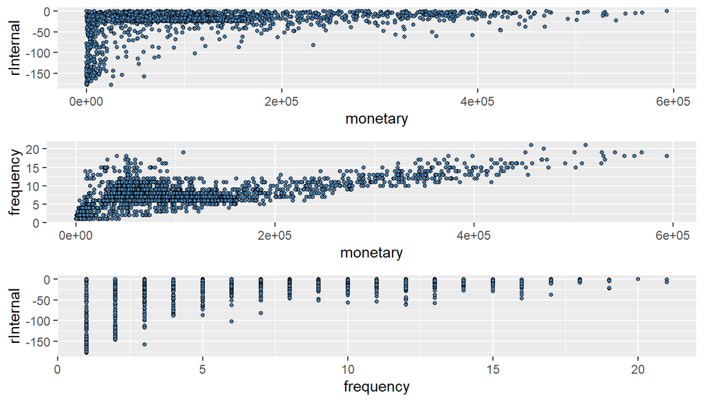

根据recency与monetary的子图可以看出，交易金额较高的人，最近一次交易的时间距离观察窗口结束的时间也较近，说明大金额交易的客户不太可能长时间不进行交易。而交易金额很低的人，最近一次交易时间相对均匀分布在(0, 200)天之间，说明loan交易总额很低的客户中，有一部分长时间不再进行loan交易，可能处于流失的状态或者时价值较低的客户。

根据frequency和monetary的子图可以看出，交易频次和总金额存在近似的线性关系。总体来看，当交易金额增大时，频次也增大。不过在交易金额较小(10万以内)时，有部分用户的交易频次也较高。

根据recency和frequency的子图可以看出，交易频次高的客户，最近一次交易间隔时间短，随着交易频次的升高，最近一次交易的时间逐渐也越近。而交易频次很低的这部分客户，可能只是在观查窗口的某个时间内随机交易了1-2次。

## 附录

这里给出其他的等级划分标准，以便对比不同等级划分标准下的分层结果。以loan交易为例进行分析，其余5种交易类型的等级划分结果可以类似给出。

**等级划分标准2** 采用分位数方法进行客户分层。根据分位数分别对rInternal(最近一次交易距离天数)，frequency(交易频次)， monetary(交易总金额)进行打分，记为新的R，F，M指标。具体来说，`rInternal`表示某客户最近一次交易日期距离参照日期的天数，为负值，因此`rInternal`越大，得分越高； `frequency`越大，得分越高；`monetary`越大，得分越高。 具体操作如下：

```r
# 距离天数越大，rInternal越大，得分越高
qr <- unique(quantile(trans_loan$rInternal))
qf <- unique(quantile(trans_loan$frequency))
qm <- unique(quantile(trans_loan$monetary))

trans_loan_rfm <- trans_loan %>%
  mutate(Rece = as.integer(cut(rInternal, breaks = c(-Inf, qr, Inf), labels = 1:(length(qr)+1)))) %>%
  mutate(Freq = as.integer(cut(frequency, breaks = c(-Inf, qf, Inf), labels = 1:(length(qf)+1)))) %>%
  mutate(Mone = as.integer(cut(monetary, breaks = c(-Inf, qm, Inf), labels = 1:(length(qm)+1)))) %>%
  select(-c(rankR, rankF, rankM, operation))
```

根据R，F，M的得分对客户进行分类，高于平均值判定为“高”，低于平均值判定为“低”。

```r
  trans_loan_rfm$rankR <- ifelse(trans_loan_rfm$Rece > mean(trans_loan_rfm$Rece), "高", "低")
  trans_loan_rfm$rankF <- ifelse(trans_loan_rfm$Freq > mean(trans_loan_rfm$Freq), "高", "低")
  trans_loan_rfm$rankM <- ifelse(trans_loan_rfm$Mone > mean(trans_loan_rfm$Mone), "高", "低")

  label <- vector("character", nrow(trans_loan_rfm))
  rfm_lab <- within(trans_loan_rfm, {

    label[rankR == "高" & rankF == "高" & rankM == "高"] = "重要价值客户"
    label[rankR == "高" & rankF == "低" & rankM == "高"] = "重要发展客户"
    label[rankR == "低" & rankF == "高" & rankM == "高"] = "重要保持客户"
    label[rankR == "低" & rankF == "低" & rankM == "高"] = "重要挽留客户"

    label[rankR == "高" & rankF == "高" & rankM == "低"] = "一般价值客户"
    label[rankR == "高" & rankF == "低" & rankM == "低"] = "一般发展客户"
    label[rankR == "低" & rankF == "高" & rankM == "低"] = "一般保持客户"
    label[rankR == "低" & rankF == "低" & rankM == "低"] = "一般挽留客户"

  })

  rfm_lab
```

```
## # A tibble: 2,848 x 13
## # Groups:   account_id, operation [2,848]
##    operation account_id recency    frequency monetary rInternal  Rece  Freq
##    <chr>          <int> <date>         <int>    <dbl>     <int> <int> <int>
##  1 loan            2378 1998-06-23        11   189095        -6     5     4
##  2 loan             704 1998-06-12         6   113601       -17     4     2
##  3 loan            3818 1998-06-09         6   112879       -20     3     2
##  4 loan            2632 1998-06-09         6    92716       -20     3     2
##  5 loan            1539 1998-06-06        13   365559       -23     2     4
##  6 loan            2484 1998-06-12         6    96063       -17     4     2
##  7 loan            1695 1998-06-06        19   541345       -23     2     4
##  8 loan            1726 1998-06-13         6    90785       -16     4     2
##  9 loan             485 1998-06-05         8   240098       -24     2     3
## 10 loan             652 1998-06-09         8    99331       -20     3     3
## # ... with 2,838 more rows, and 5 more variables: Mone <int>, rankR <chr>,
## #   rankF <chr>, rankM <chr>, label <chr>
```

汇总统计各个客户组的人数和占比情况，绘制相应的条形图：

| 客户类型 | 计数 | 占比 | 成交客户等级 |
| --- | --- | --- | --- |
| 重要价值客户 | 431 | 0.1513 | A级 |
| 重要发展客户 | 253 | 0.0888 | A级 |
| 重要保持客户 | 225 | 0.0790 | B级 |
| 重要挽留客户 | 514 | 0.1805 | B级 |
| 一般价值客户 | 332 | 0.1166 | B级 |
| 一般发展客户 | 233 | 0.0818 | B级 |
| 一般保持客户 | 290 | 0.1018 | C级 |
| 一般挽留客户 | 570 | 0.2001 | C级 |

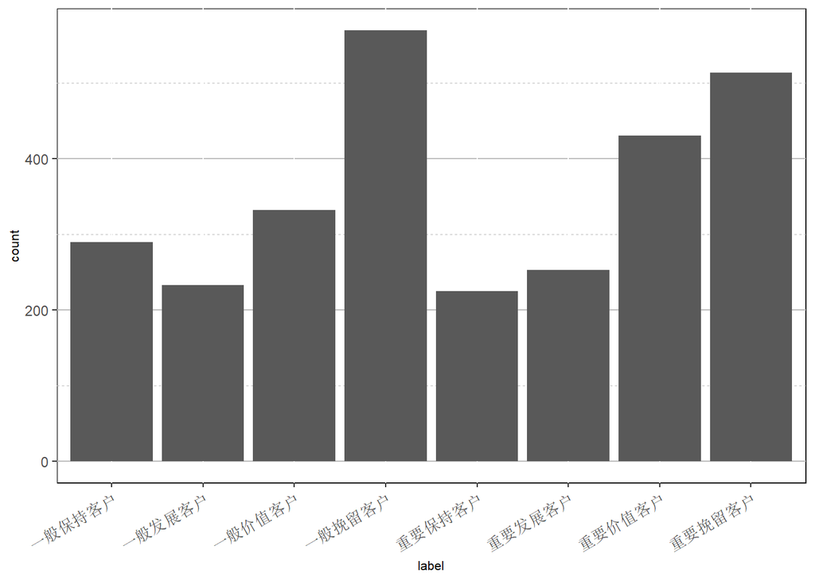

```r
ggplot(data = rfm_lab) + geom_bar(mapping = aes(x = label)) + mytheme
```

汇总各个客户组的recency，frequency，monetary的均值和中位数

```r
rfm_lab %>% group_by(label) %>%
  summarize(rmean = mean(rInternal), rmedian = median(rInternal), rsd = sd(rInternal),
            fmean = mean(frequency), fmedian = median(frequency), fsd = sd(frequency),
            mmean = mean(monetary),  mmedian = median(monetary),  msd = sd(monetary),
            .groups = "drop")
```

```
## # A tibble: 8 x 10
##   label         rmean rmedian   rsd fmean fmedian   fsd   mmean mmedian     msd
##   <chr>         <dbl>   <dbl> <dbl> <dbl>   <dbl> <dbl>   <dbl>   <dbl>   <dbl>
## 1 一般保持客户 -21.1      -21  2.10  8.36       8 1.43   64369.   63589  17823.
## 2 一般发展客户 -10.9      -14  5.80  4.77       6 1.62   45204.   42800  31885.
## 3 一般价值客户 -11.3      -12  5.27 10.1        9 2.79   58062.   58297  21313.
## 4 一般挽留客户 -55.4      -26 47.1   3.90       4 2.05   38848.   34541  32813.
## 5 重要保持客户 -25.8      -22  9.86  9.39       8 2.57  197198.  164364  98094.
## 6 重要发展客户 -14.5      -16  4.06  5.89       6 0.441 130556.  130331  20379.
## 7 重要价值客户  -7.54      -6  5.45 10.8       11 3.22  250445.  237729 115912.
## 8 重要挽留客户 -22.9      -22  8.29  5.92       6 0.352 132051.  131622  19831.
```

将8个客户组的recency，frequency，monetary的均值、中位数和方差，汇总如下：

loan交易中客户R，F，M指标的统计量汇总–分位数法

| 客户类型 | R均值 | R中位数 | R标准差 | F均值 | F中位数 | F标准差 | M均值 | M中位数 | M标准差 |
| --- | --- | --- | --- | --- | --- | --- | --- | --- | --- |
| 重要价值客户 | -7.54 | -6 | 5.45 | 10.8 | 11 | 3.22 | 250445 | 237729 | 115912 |
| 重要发展客户 | -14.5 | -16 | 4.06 | 5.89 | 6 | 0.441 | 130556 | 130331 | 20379 |
| 重要保持客户 | -25.8 | -22 | 9.86 | 9.39 | 8 | 2.57 | 197198 | 164364 | 98094 |
| 重要挽留客户 | -22.9 | -22 | 8.29 | 5.92 | 6 | 0.352 | 132051 | 131622 | 19831 |
| 一般价值客户 | -11.3 | -12 | 5.27 | 10.1 | 9 | 2.79 | 58062 | 58297 | 21313 |
| 一般发展客户 | -10.9 | -14 | 5.80 | 4.77 | 6 | 1.62 | 45204 | 42800 | 31885 |
| 一般保持客户 | -21.1 | -21 | 2.10 | 8.36 | 8 | 1.43 | 64369 | 63589 | 17823 |
| 一般挽留客户 | -55.4 | -26 | 47.1 | 3.90 | 4 | 2.05 | 38848 | 34541 | 32813 |

**等级划分标准3** 采用聚类方法进行客户分层。这里做一个简单的例子提供参考，由于数据本身比较简单，根据RFM三个指标的话使用均值或者分位数的分层方法就足够。进行聚类前的基本操作有(可选)： (1) R，F，M三个指标标准化; (2) R，F，M三个指标加权; (3) 加权综合RFM指标;

根据以上操作得到的新指标进行K-Means聚类并作结果分析。

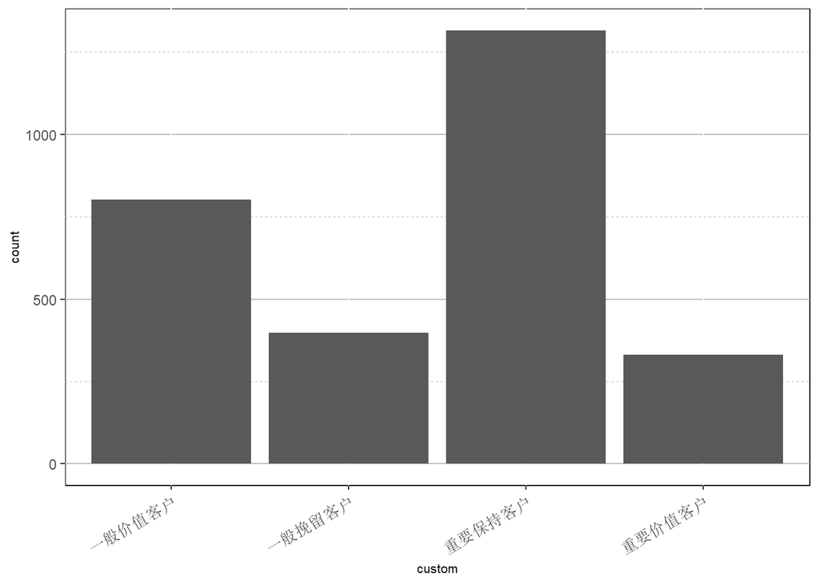

```r
loan_model <- trans_loan[, c("rInternal", "frequency", "monetary")]
loan_new <- apply(loan_model, 2, scale) %>% as_tibble() %>% mutate(WZR = 0.2*rInternal) %>%
  mutate(WZF = 0.3*frequency) %>% mutate(WZM = 0.5*monetary) %>% select(WZR, WZF, WZM)

if(!require(factoextra)) {install.packages("factoextra"); library(factoextra)}

km_loan <- kmeans(loan_new, 8)
loan_clust <- tibble(loan_new, clust = km_loan$cluster)

##对比每类客户的RFM均值与总的RFM均值，大于总平均值记为“高”， 小于总平均值记为“低”
clust_center <- as_tibble(km_loan$centers)
clust_center <- clust_center %>%
  mutate(rankR = ifelse(clust_center[["WZR"]] > apply(loan_new, 2, median)[1], "高", "低")) %>%
  mutate(rankF = ifelse(clust_center[["WZF"]] > apply(loan_new, 2, median)[2], "高", "低")) %>%
  mutate(rankM = ifelse(clust_center[["WZM"]] > apply(loan_new, 2, median)[3], "高", "低"))

custom <- vector("character", length = 8)
clust_center <- within(clust_center, {
    custom[rankR == "高" & rankF == "高" & rankM == "高"] = "重要价值客户"
    custom[rankR == "高" & rankF == "低" & rankM == "高"] = "重要发展客户"
    custom[rankR == "低" & rankF == "高" & rankM == "高"] = "重要保持客户"
    custom[rankR == "低" & rankF == "低" & rankM == "高"] = "重要挽留客户"

    custom[rankR == "高" & rankF == "高" & rankM == "低"] = "一般价值客户"
    custom[rankR == "高" & rankF == "低" & rankM == "低"] = "一般发展客户"
    custom[rankR == "低" & rankF == "高" & rankM == "低"] = "一般保持客户"
    custom[rankR == "低" & rankF == "低" & rankM == "低"] = "一般挽留客户"
})

clust_refer <- tibble(clust = 1:8, custom = clust_center$custom)

loan_clust <- inner_join(loan_clust, clust_refer, by = "clust")

ggplot(data = loan_clust) +
       geom_bar(mapping=aes(x = custom)) + mytheme
```

### 总结

1. 客户细分的方法有很多，这里使用RFM模型对客户进行细分，是最基本客户划分方法，只针对客户的交易近度(Recency)、交易频率(Frequency)、交易金额(Monetary)进行统计，来体现出一个客户的粘性以及活跃度。还可以根据客户的风险来进行客户细分。
2. “重要发展客户”是指最近在进行交易，交易金额高，但交易频次不高的客户，说明客户具有财富价值，经常进行大额交易，是非常好的营销对象，可以推销产品.
3. “一般发展客户”和“一般价值客户”的交易金额低，不体现较大的价值。对于这类客户，银行所提供的服务相对较少，很多银行把他们划分到低优先级，在做业务的时候，不会将他们放在靠前位置。一般来说优先级高的都是当前很有价值或者是曾经很有价值的客户。